# Phenotyping

2022-08-14

# Cell phenotyping

A common step during single-cell data analysis is the annotation of cells based on their phenotype. Defining cell phenotypes is often subjective and relies on previous biological knowledge. The [Orchestrating Single Cell Analysis with Bioconductor](https://bioconductor.org/books/3.14/OSCA.basic/cell-type-annotation.html) book presents a number of approaches to phenotype cells detected by single-cell RNA sequencing based on reference datasets or prior knowledge of geneset importance.

In highly-multiplexed imaging, target proteins or molecules are manually selected based on the biological question at hand. It narrows down the feature space and facilitates the manual annotation of clusters to derive cell phenotypes. We will therefore discuss and compare a number of clustering approaches to group cells based on their similarity in marker expression in Section @ref(clustering).

Unlike single-cell RNA sequencing or CyTOF data, single-cell data derived from highly-multiplexed imaging data often suffers from “lateral spillover” between neighboring cells. This spillover caused by imperfect segmentation often hinders accurate clustering to define specific cell phenotypes in multiplexed imaging data. Tools have been developed to correct lateral spillover between cells [@Bai2021] but the approach requires careful selection of the markers to correct. In Section @ref(classification) we will train and apply a random forest classifier to classify cell phenotypes in the dataset as alternative approach for clustering-based cell phenotyping. This approach has been previously used to identify major cell phenotypes in metastatic melanoma and avoids clustering of cells [@Hoch2022].

## Load data

```r
library(SpatialExperiment)
path <- "/mnt/Multimodal_Imaging_Daria/_Data_Analysis/_tmp_daria/Image_analysis/20220723_Steinbock_Mesmer_IFbased"
spe <- readRDS(file.path(path,"data/spe.rds"))

# Sample cells
set.seed(220619)
cur_cells <- sample(seq_len(ncol(spe)), 20000)
```

## Clustering approaches

### Rphenograph

The PhenoGraph clustering approach was first described to group cells of a CyTOF dataset [@Levine2015]. The algorithm first constructs a graph by detecting the `k` nearest neighbours based on euclidean distance in expression space. In the next step, edges between nodes (cells) are weighted by their overlap in nearest neighbor sets. To quantify the overlap in shared nearest neighbor sets, the jaccard index is used. The Louvain modularity optimization approach is used to detect connected communities and partition the graph into cluster of cells. This clustering strategy was used by Jackson, Fischer *et al.* to cluster IMC data [@Jackson2020].

There are several different PhenoGraph implementations available in R. Here, we use the one available at https://github.com/i-cyto/Rphenograph. For large datasets, https://github.com/stuchly/Rphenoannoy offers a more performant implementation of the algorithm.

Here we will test [fastPG](https://www.biorxiv.org/content/10.1101/2020.06.19.159749v1.full.pdf) as the fast implementation of Phenograph, as it is reported to be more accurate than FlowSOM.

```r
n_threads <- detectCores()

mat <- reducedDim(spe, "harmony")

#out <- Rphenograph(mat, k = 45)
out <- FastPG::fastCluster(data=mat, k=45, num_threads=n_threads)

clusters <- factor(out$communities)

spe$pg_clusters <- clusters

dittoDimPlot(spe, var = "pg_clusters",
             reduction.use = "UMAP", size = 0.2,
             do.label = TRUE) +
    ggtitle("Phenograph clusters expression on UMAP")
```

[output not shown]

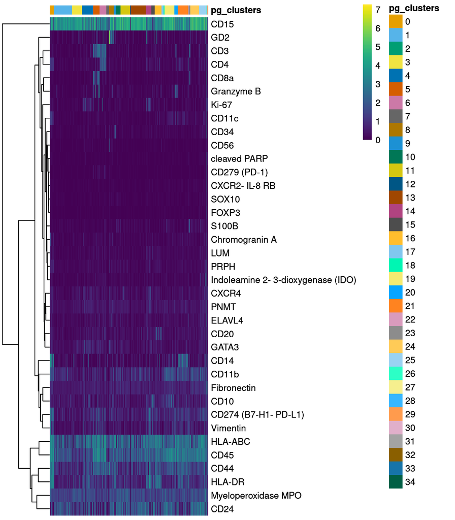

```r
dittoHeatmap(spe[,cur_cells],
             genes = rownames(spe)[rowData(spe)$use_channel],
             assay = "exprs", scale = "none",
             heatmap.colors = viridis(100),
             annot.by = "pg_clusters",
             annot.colors = dittoColors(1)[1:length(unique(spe$pg_clusters))])
```

We will also look at all cells to avoid missing rare cell types.

[figure not shown]

```r
dittoHeatmap(spe,
             genes = rownames(spe)[rowData(spe)$use_channel],
             assay = "exprs", scale = "none",
             heatmap.colors = viridis(100),
             annot.by = "pg_clusters_corrected",
             annot.colors = dittoColors(1)[1:length(unique(spe$pg_clusters_corrected))])
```

We don’t really find rare cells.

Here we will test [fastPG](https://www.biorxiv.org/content/10.1101/2020.06.19.159749v1.full.pdf) as the fast implementation of Phenograph, as it is reported to be more accurate than FlowSOM.

```r
n_threads <- detectCores()

mat <- reducedDim(spe, "harmony")

out <- FastPG::fastCluster(data=mat, k=45, num_threads=n_threads)

clusters <- factor(out$communities)

spe$pg_clusters_corrected <- clusters

dittoDimPlot(spe, var = "pg_clusters_corrected",
             reduction.use = "UMAP_harmony", size = 0.2,
             do.label = TRUE) +
    ggtitle("Phenograph clusters expression on UMAP, integrated cells")
```

[output not shown]

We immediately see that we get less clusters.

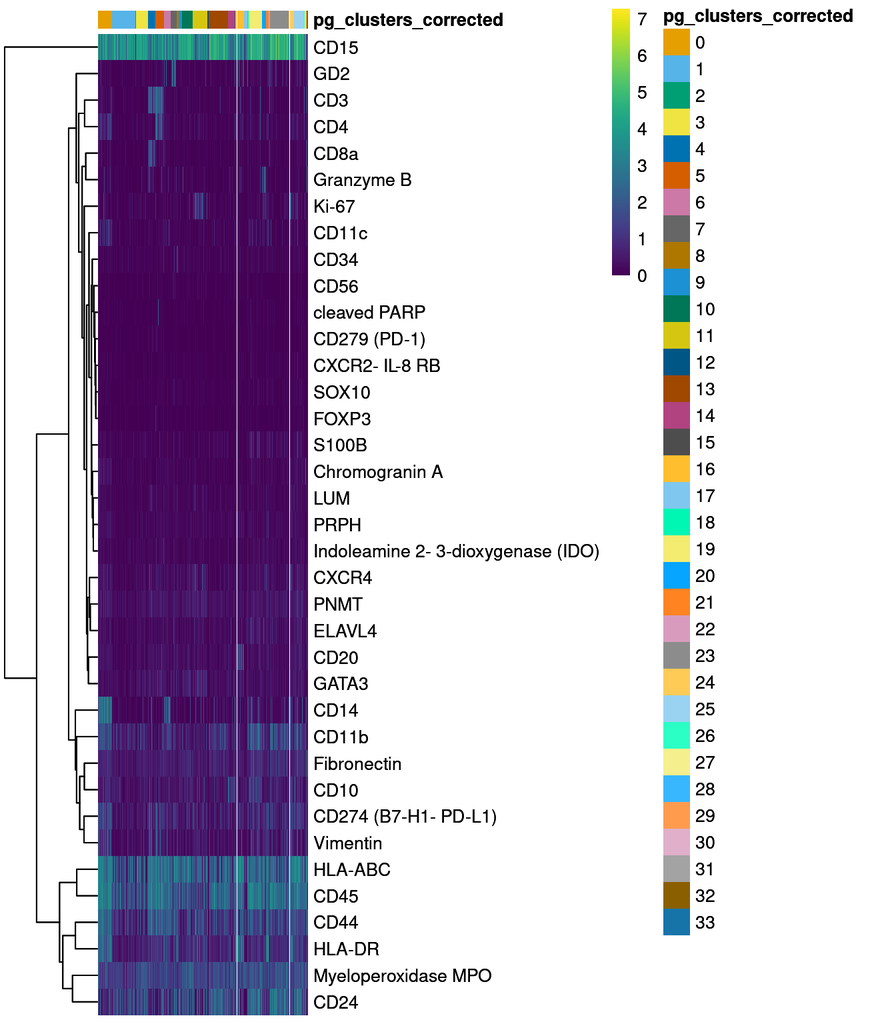

```r
dittoHeatmap(spe[,cur_cells],
             genes = rownames(spe)[rowData(spe)$use_channel],
             assay = "exprs", scale = "none",
             heatmap.colors = viridis(100),
             annot.by = "pg_clusters_corrected",
             annot.colors = dittoColors(1)[1:length(unique(spe$pg_clusters_corrected))])
```

We observe that we get more segregated clusters with biologically more realisitic assignment of cells. We see a clear HLA-DR+ CD14+ CD274+ CD11c+ cluster which could represent monocytes/macrophages and dendritic cells. We see clearT-cells clusters with activated T-cells expressing CD8 and Granzyme B. We see an interesting cluster of proliferating cells expressing Ki-67, GAT3, CXCR4 and ElAVL4. We see a tumor cluster expressing GD2, CD56, ELAVL4 and GATA3. Another cluster expresses CD24, CD10 and CD11b. CD45, HLA-ABC and MPO are very homogeneously expressed.

[figure not shown]

```r
dittoHeatmap(spe,
             genes = rownames(spe)[rowData(spe)$use_channel],
             assay = "exprs", scale = "none",
             heatmap.colors = viridis(100),
             annot.by = "pg_clusters_corrected",
             annot.colors = dittoColors(1)[1:length(unique(spe$pg_clusters_corrected))])
```

As some markers have really low expressions, we will look a min-max scale rows.

[figure not shown]

```r
dittoHeatmap(spe,
             genes = rownames(spe)[rowData(spe)$use_channel],
             assay = "exprs", scaled.to.max="TRUE",
             annot.by = "pg_clusters_corrected",
             annot.colors = dittoColors(1)[1:length(unique(spe$pg_clusters_corrected))])
```

And as a last step, let’s show the mean per cluster.

```r
# library(scuttle)
#
# image_mean <- aggregateAcrossCells(spe,
#                                     ids = spe$pg_clusters_corrected,
#                                     statistics="mean",
#                                     use.assay.type = "counts")
# assay(image_mean, "exprs") <- asinh(counts(image_mean))
#
# #not scaled
# image_mean%>%dittoHeatmap(genes = rownames(spe)[rowData(spe)$use_channel],
#             assay = "exprs", cluster_cols = TRUE, scale = "none",
#             heatmap.colors = viridis(100),
#             annot.by = c("sample"),
#             annot.colors = c(dittoColors(1)[1:length(unique(spe$pg_clusters_corrected))],
#                             metadata(spe)$color_vectors$sample),
#             show_colnames = FALSE)
#
# #scaled
# image_mean%>%dittoHeatmap(genes = rownames(spe)[rowData(spe)$use_channel],
#             assay = "exprs", cluster_cols = TRUE, scaled.to.max="TRUE",
#             heatmap.colors = viridis(100),
#             annot.by = c("sample"),
#             annot.colors = c(dittoColors(1)[1:length(unique(spe$pg_clusters_corrected))],
#                             metadata(spe)$color_vectors$sample),
#             show_colnames = FALSE)

#gives error: Error in .local(x, ..., value) :
  #Number of unique 'sample_id's is 7, but 1 was provided.
```

### Self organizing maps

An alternative to graph-based clustering is offered by the [CATALYST](https://bioconductor.org/packages/release/bioc/html/CATALYST.html) package. The `cluster` function internally uses the [FlowSOM](https://bioconductor.org/packages/release/bioc/html/FlowSOM.html) package to group cells into 100 (default) clusters based on self organizing maps (SOM). In the next step, the [ConsensusClusterPlus](https://bioconductor.org/packages/release/bioc/html/ConsensusClusterPlus.html) package is used to perform hierarchical consensus clustering of the previously detected 100 SOM nodes into 1 to `maxK` clusters. Cluster stability for each `k` can be assessed by plotting the `delta_area(spe)`. The optimal number of clusters can be found by selecting the `k` at which a plateau is reached. In the example below, the optimal `k` lies somewhere around 13.

```r
# Run FlowSOM and ConsensusClusterPlus clustering
spe <- cluster(spe,
               features = rownames(spe)[rowData(spe)$use_channel],
               maxK = 30,
               seed = 220410)

# Assess cluster stability
delta_area(spe)

spe$som_clusters <- cluster_ids(spe, "meta13")

dittoDimPlot(spe, var = "som_clusters",
             reduction.use = "UMAP", size = 0.2,
             do.label = TRUE) +
    ggtitle("SOM clusters expression on UMAP")
```

[output not shown]

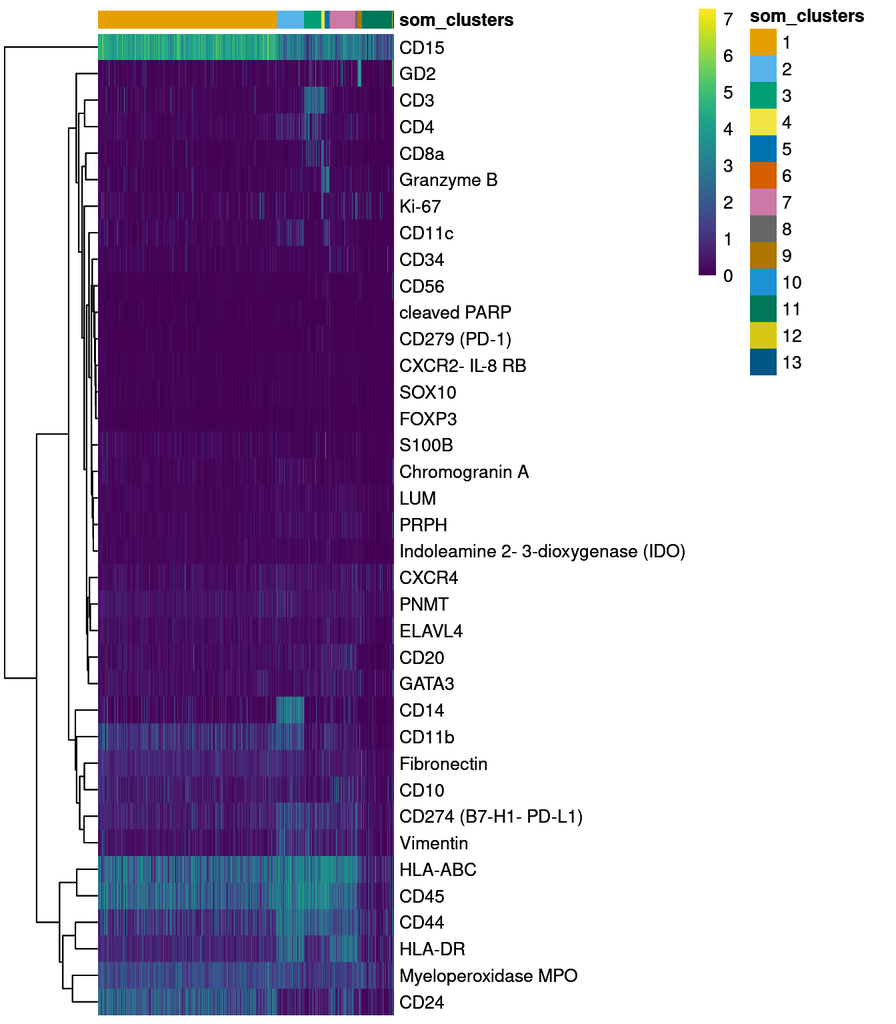

```r
dittoHeatmap(spe[,cur_cells],
             genes = rownames(spe)[rowData(spe)$use_channel],
             assay = "exprs", scale = "none",
             heatmap.colors = viridis(100),
             annot.by = "som_clusters",
             annot.colors = dittoColors(1)[1:length(unique(spe$som_clusters))])
```

The flowSOM clustering looks very different as compared to the PG clustering. We detect a huge CD15+ CD24+ cluster, which might represent neutrohpils. It would be interesting to perform hierarchical clustering among those cells to find different levels of maturity. Also improvement of the segmentation might help to take into account nuclear roundness. We detect a large CD14+ cluster, tumor cells (GD2+, ELAVL4+, CD56+ and GATA3+). We detect B-cells (CD20+ HLA-DR+) and T-cells (CD3+, CD4+, CD8+, Granzyme B).

Running FlowSOM clustering took 0.12 minutes.

```r
# Select integrated cells
mat <- reducedDim(spe, "harmony")

# Perform SOM clustering
som.out <- clusterRows(mat, SomParam(100), full = TRUE)
# Cluster the 100 SOM codes into larger clusters
ccp <- ConsensusClusterPlus(t(som.out$objects$som$codes[[1]]),
                            maxK = 30,
                            reps = 100,
                            distance = "euclidean",
                            seed = 220410,
                            plot = NULL)
```

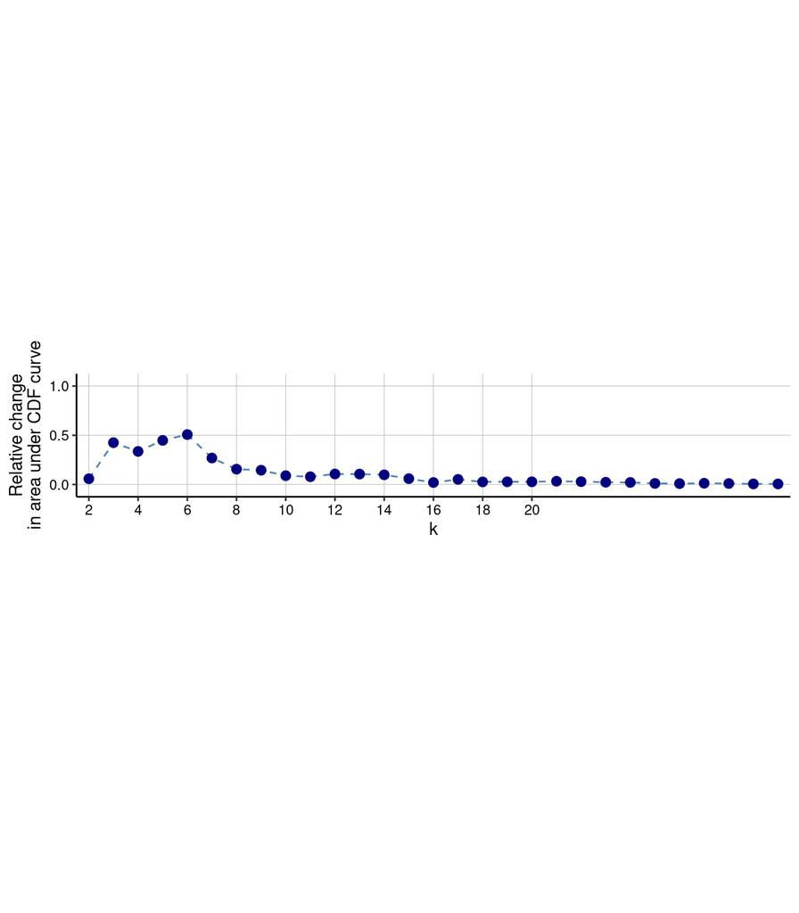

```r
# Visualize delta area plot
CATALYST:::.plot_delta_area(ccp)
```

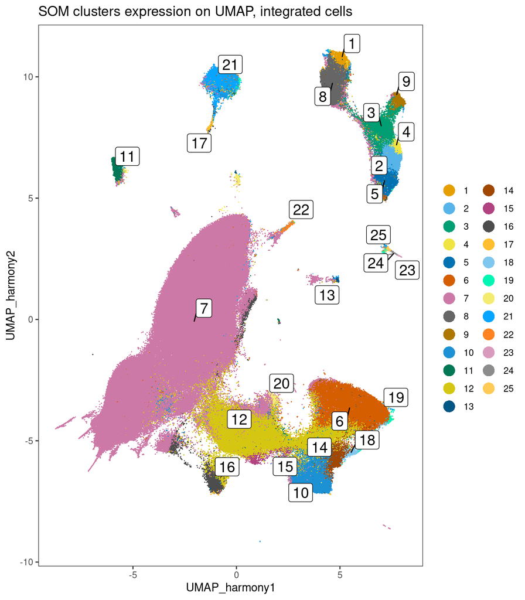

```r
# Link ConsensusClusterPlus clusters with SOM codes and save in object
som.cluster <- ccp[[25]][["consensusClass"]][som.out$clusters]
spe$som_clusters_corrected <- as.factor(som.cluster)

dittoDimPlot(spe, var = "som_clusters_corrected",
             reduction.use = "UMAP_harmony", size = 0.2,
             do.label = TRUE) +
    ggtitle("SOM clusters expression on UMAP, integrated cells")
```

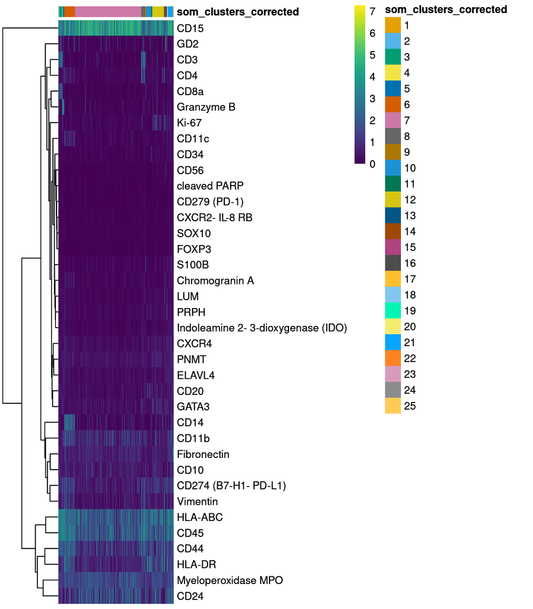

```r
dittoHeatmap(spe[,cur_cells],
             genes = rownames(spe)[rowData(spe)$use_channel],
             assay = "exprs", scale = "none",
             heatmap.colors = viridis(100),
             annot.by = "som_clusters_corrected",
             annot.colors = dittoColors(1)[1:length(unique(spe$som_clusters_corrected))])
```

Again, we see a huge cluster pointing towards neutrophils. Sticky cells can be seen (positive for everything). Here, it looks like the uncorrected heatmap is more informative.

[figure not shown]

```r
dittoHeatmap(spe,
             genes = rownames(spe)[rowData(spe)$use_channel],
             assay = "exprs", scaled.to.max="TRUE",
             annot.by = "som_clusters_corrected",
             annot.colors = dittoColors(1)[1:length(unique(spe$som_clusters_corrected))])
```

The `FlowSOM` clustering approach has been used by [@Hoch2022] to sub-cluster tumor cells as measured by IMC.

### Compare between clustering approaches

Finally, we can compare the results of different clustering approaches. For this, we visualize the number of cells that are shared between different clustering results in a pairwise fashion. In the following heatmaps a high match between clustering results can be seen for those clusters that are uniquely detected in both approaches.

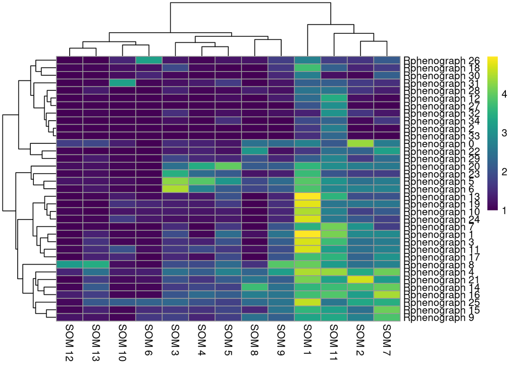

```r
library(patchwork)
library(pheatmap)
library(gridExtra)

tab1 <- table(paste("Rphenograph", spe$pg_clusters),
              paste("SOM", spe$som_clusters))

pheatmap(log10(tab1 + 10), color = viridis(100))
```

Below, a comparison between the clustering results of the integrated cells is shown.

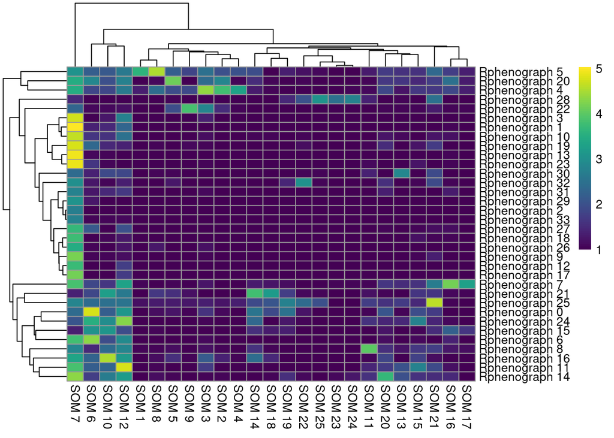

```r
tab1 <- table(paste("Rphenograph", spe$pg_clusters_corrected),
              paste("SOM", spe$som_clusters_corrected))

pheatmap(log10(tab1 + 10), color = viridis(100))
```

In comparison to clustering on the non-integrated cells, the clustering results of the integrated cells show higher overlap.

### Further clustering notes

Finally, we save the updated `SpatialExperiment` object.

```r
saveRDS(spe, file.path(path,"data/spe.rds"))
```